# Alzheimer’s and Parkinson’s disease, Sleep and Mental Health

Ellen Spencer

2023-05-04

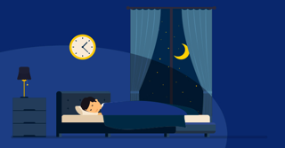

# Background

Parkinson’s disease and Alzheimer’s disease are two common neurodegenerative diseases, affecting many individuals worldwide. Alzheimer’s disease is characterised by a loss of cognitive functioning and the ability to carry out every day activities. Parkinson’s disease is a condition whereby individuals are unable to control their movements, leading to difficulties initiating and coordinating movement, shaking, stiffness and other behavioural changes. Research has extensively been conducted regarding these two diseases, and a common finding suggests that both diseases are associated with various sleep disturbances and disorders (Peter-Derex et al., 2015; Comella, 2007).

## Research Question

This aim of this project was to explore how length of sleep differed between those with neither disease, Alzheimer’s disease, Parkinson’s disease and both diseases. Furthermore, this project also aimed to assess how mental health influenced length of sleep in these diseases.

# Setup of the project

**Firstly I loaded the libraries that were to be used for this project.**

```r
# Load libraries that the project will use
library(here)
library(tidyverse)
library(RColorBrewer)
```

**Then I loaded the data into R and assigned it to a data frame.**

```r
# Use library(here) to import the data and assign it to a data frame
df <- read_csv(here("Data", "raw_data.csv"))
```

```r
# Check data frame
head(df)
```

| ...1 | ID | AGE | DEMENTIA | ALZHEIMER | GENDER | EDUC | RACE_RECODE | PARKINSON | MNTLHLTH | ASSUMED_SLEEP | WASO | ACTIGRAPH_SLEEP |
| --- | --- | --- | --- | --- | --- | --- | --- | --- | --- | --- | --- | --- |
| 1 | 100033 | 84 | (0) no | (0) no | (2) female | (3) voc cert/some college/assoc | (1) white/caucasian | (0) no | (5) excellent | 159.50 | 11.75 | 147.75 |
| 2 | 100033 | 84 | (0) no | (0) no | (2) female | (3) voc cert/some college/assoc | (1) white/caucasian | (0) no | (5) excellent | 236.00 | 8.00 | 228.00 |
| 3 | 100067 | 65 | (0) no | (0) no | (2) female | (2) hs/equiv | (3) asian, pacific islander, american indian or alaskan native | (0) no | (3) good | 467.25 | 23.50 | 443.75 |
| 4 | 100067 | 65 | (0) no | (0) no | (2) female | (2) hs/equiv | (3) asian, pacific islander, american indian or alaskan native | (0) no | (3) good | 464.25 | 18.75 | 445.50 |
| 5 | 100067 | 65 | (0) no | (0) no | (2) female | (2) hs/equiv | (3) asian, pacific islander, american indian or alaskan native | (0) no | (3) good | 406.25 | 16.75 | 389.50 |
| 6 | 100149 | 70 | (0) no | (0) no | (2) female | (2) hs/equiv | (1) white/caucasian | (0) no | (5) excellent | 356.25 | 6.25 | 350.00 |

# Data wrangling

**To begin to clean the data, I created a new data frame which contained only the columns of interest to the project which were renamed for ease. This new data frame also had non-numerical information discarded from the Alzheimer’s and Parkinson’s disease columns, and numerical information removed from the mental health column.**

```r
# Make new data frame looking only at columns of interest which have been renamed for ease
# and have had non-numerical information removed from the disease state columns, and
# numerical information discarded from the mental health column
df1 <- df %>%
  rename(ppt_id = "ID", dementia = "DEMENTIA", alzheimers = "ALZHEIMER", mental_health =
           "MNTLHLTH", parkinsons = "PARKINSON", sleep_length = "ACTIGRAPH_SLEEP") %>%
  select(ppt_id, alzheimers, parkinsons, mental_health, sleep_length) %>%
  mutate(alzheimers = parse_number(str_sub(alzheimers, start = 1))) %>%
  mutate(parkinsons = parse_number(str_sub(parkinsons, start = 1))) %>%
  mutate(mental_health = str_sub(mental_health, start = 5, end = 13))

# Check the first few lines of the data
head(df1)
```

| ppt_id | alzheimers | parkinsons | mental_health | sleep_length |
| --- | --- | --- | --- | --- |
| 100033 | 0 | 0 | excellent | 147.75 |
| 100033 | 0 | 0 | excellent | 228.00 |
| 100067 | 0 | 0 | good | 443.75 |
| 100067 | 0 | 0 | good | 445.50 |
| 100067 | 0 | 0 | good | 389.50 |
| 100149 | 0 | 0 | excellent | 350.00 |

**Next I removed all NA values from the data frame.**

```r
# Remove NA values from the data.
which(is.na(df1), arr.ind = TRUE)
df1 <- na.omit(df1)
```

**Following this, I then created a new ‘disease state’ column within the data frame, where the four potential disease states present in the data were represented numerically, with 0 representing those with neither disease, 1 representing Alzheimer’s disease, 2 representing Parkinson’s disease and 3 representing a combination of the two diseases.**

```r
# Change values in Parkinson's disease column from '1' to '2'.
df1$parkinsons[df1$parkinsons == '1'] <- 2

# Add the Parkinson's disease column and Alzheimer's disease columns together to make a
# new disease state column, where 0 is neither, 1 is Alzheimer's, 2 is Parkinson's and 3
# is both.
df1$disease_state <- df1$parkinsons + df1$alzheimers
```